# The Working Moms

# Introduction

The 2013 American Community Survey run by the US Census Bureau provides a rich dataset with detailed information of approximately 3.5 million households regarding to topics such as ancestry, education, employment, and residency. Being a working mom myself, I’m particularly interested in a descriptive analysis of the employment status of the American moms with dependent children younger than 18 years old.

### Dataset

The variables including information of region, age, marital status, presence of kids, employment status, education, and wage were read into R and saved as pus.Rdata. Male at any age and female younger than 16 years old were removed from the dataset by omitting the instances with NA in the PAOC (presence of own children) variable.

```r
#library(data.table)
#cols <- c("PAOC", "ST", "AGEP", "MAR", "ESR", "COW", "SCHL", "WAGP")
#pusa <- fread("ss13pusa.csv", select = cols)
#pusb <- fread("ss13pusb.csv", select = cols)
#pus <- subset(rbind(pusa, pusb), !is.na(PAOC))
#save(pus, file = "pus.Rdata")
```

The catagorical variables were labled according to ACS data dictionary. The am dataset contained three groups of moms including moms with little kids (“children under 6”), moms with big kids (“children 6 to 17”), and moms with little kids and big kids (“children under 6 and 6 to 17”) according to the information of presence of children (PAOC).

```r
library(ggplot2)
library(dplyr)
library(gridExtra)
library(maps)
load("pus.Rdata")

pus$MAR <- factor(pus$MAR)
levels(pus$MAR) <- c("Married", "Widowed", "Divorced", "Separated", "Never married")

pus$ESR <- factor(pus$ESR)
levels(pus$ESR) <- c("Employed", "Employed, not at work", "Unemployed", "Employed", "Employed, not at work", "Not in labor force")
pus$ESRG <- ifelse(pus$ESR == "Employed", 1, 0)

pus$COW <- factor(pus$COW)
levels(pus$COW) <- c("Private profit", "Private non-profit", "Local government", "State government", "Federal government", "Self-employed", "Self-employed", "Working without pay", "Unemployed")

pus$PAOC <- factor(pus$PAOC)
levels(pus$PAOC) <- c("Children under 6", "Children 6 to 17", "Children under 6 and 6 to 17", "No children")
pus$PAOCG <- ifelse(pus$PAOC == "No children", 0, 1)

pus$SCHL <- ifelse(pus$SCHL <= 16, 16, pus$SCHL)
pus$SCHL <- ifelse(pus$SCHL >= 17 & pus$SCHL <= 19, 19, pus$SCHL)
pus$SCHL <- factor(pus$SCHL)
levels(pus$SCHL) <- c("High school or lower", "Some college", "Associate's degree", "Bachelor's degree", "Master's degree", "Professional degree", "Doctorate degree")

am <- subset(pus, PAOCG == 1)
```

# Overview of the American Moms

### Age

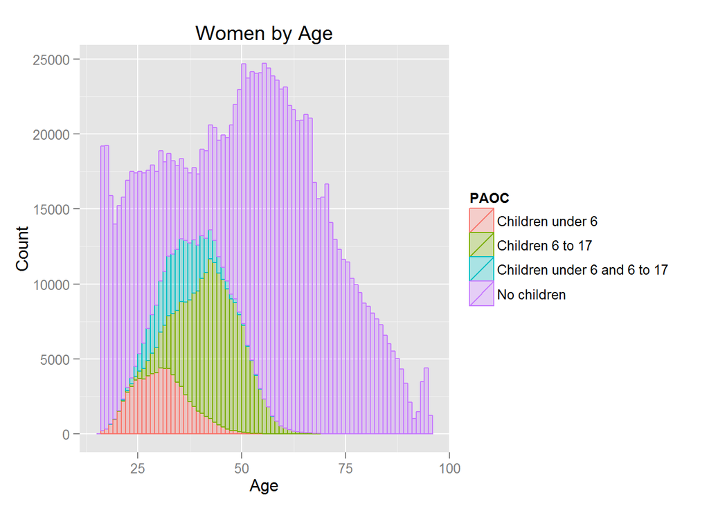

```r
ggplot(pus, aes(AGEP, group = PAOC)) +
  geom_bar(binwidth = 1, aes(colour = PAOC, fill = PAOC), alpha = 0.3) +
  xlab("Age") +
  ylab("Count") +
  ggtitle("Women by Age")
```

```r
prop.table(table(pus$PAOC))
```

```
##
##             Children under 6             Children 6 to 17
##                   0.05820400                   0.14697857
## Children under 6 and 6 to 17                  No children
##                   0.04893474                   0.74588269
```

```r
by(pus$AGEP, pus$PAOCG, summary)
```

```
## pus$PAOCG: 0
##    Min. 1st Qu.  Median    Mean 3rd Qu.    Max.
##   16.00   37.00   56.00   52.83   67.00   95.00
## --------------------------------------------------------
## pus$PAOCG: 1
##    Min. 1st Qu.  Median    Mean 3rd Qu.    Max.
##   16.00   32.00   38.00   38.37   45.00   93.00
```

### Observation

Being a mom with dependent children is a transient stage in a women’s life. Roughly a quarter of the women older than 16 were with dependent children, and only 5.8% of them were with little kids younger than 6 years old. The age distribution of the moms was bell-shaped with a median value of 38 and interquantile range of 13. The median ages of moms with little kids, moms with big kids, and moms with both were 30, 43, and 34 respectively.

### Marital Status

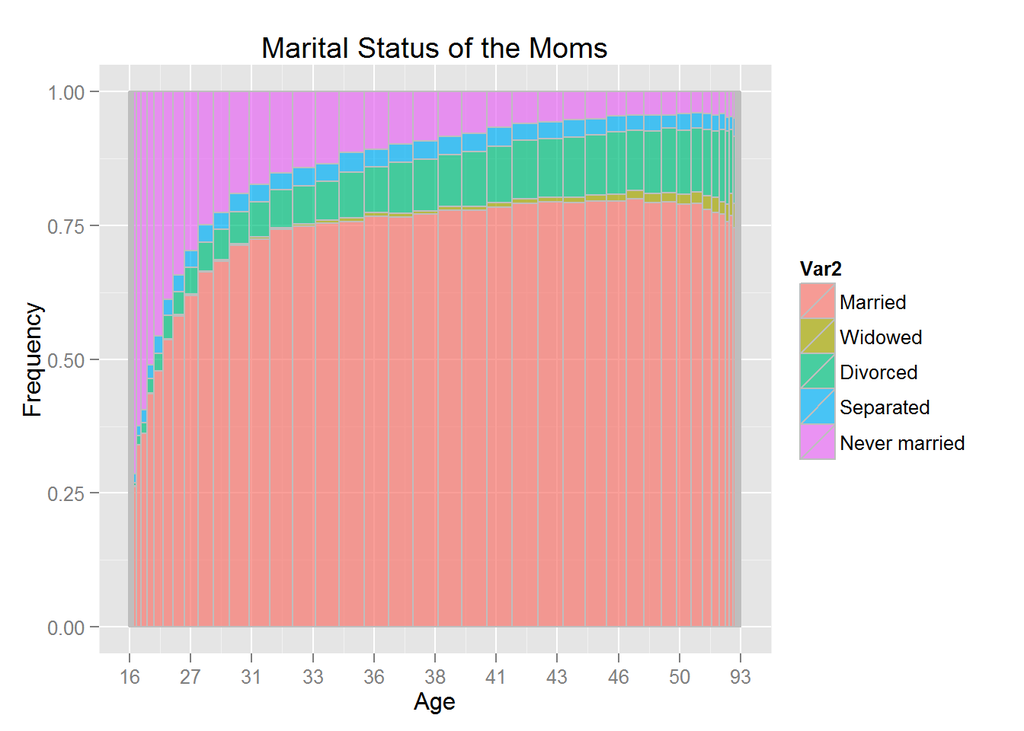

```r
data <- as.data.frame(prop.table(table(am$AGEP, am$MAR)))
data$margin <- prop.table(table(am$AGEP))
data$height <- data$Freq/data$margin
data$center <- c(0, cumsum(data$margin)[1:length(levels(factor(am$AGEP))) -1]) + data$margin/2
ggplot(data, aes(center, height)) +
  geom_bar(stat = "identity", aes(width = margin, fill = Var2), col = "gray", alpha = 0.7) +
  labs(x = "Age", y = "Frequency", title = "Marital Status of the Moms") +
  scale_x_continuous(breaks = seq(0, 1, 0.1), labels=c("16", "27", "31", "33", "36", "38", "41", "43", "46", "50", "93"))
```

### Observation

Roughly three quarters of the moms with dependent children were married, and the percentage of being married remained relatively constant among the moms in their 30s or 40s. The single moms at younger age were more likely to be never married, while the single moms at older age were more likely to be divorced or separated.

### Education Level

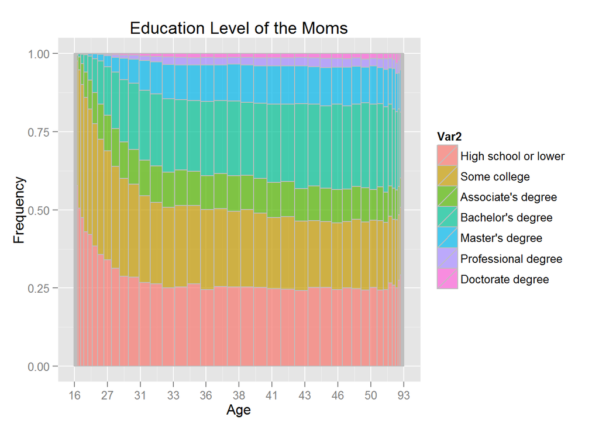

```r
data <- as.data.frame(prop.table(table(am$AGEP, am$SCHL)))
data$margin <- prop.table(table(am$AGEP))
data$height <- data$Freq/data$margin
data$center <- c(0, cumsum(data$margin)[1:length(levels(factor(am$AGEP))) -1]) + data$margin/2
ggplot(data, aes(center, height)) +
  geom_bar(stat = "identity", aes(width = margin, fill = Var2), col = "gray", alpha = 0.7) +
  labs(x = "Age", y = "Frequency", title = "Education Level of the Moms") +
  scale_x_continuous(breaks = seq(0, 1, 0.1), labels=c("16", "27", "31", "33", "36", "38", "41", "43", "46", "50", "93"))
```

### Observation

Approximately one third of the moms with dependent children possessed a Bachelor’s degree or higher. The moms in their 30s or 40s showed higher education level compared to the moms at their young age, eg., 17% of the moms at age 45 had a Master’s degree or higher in comparison to 2% of the moms at age 25.

# The Working Moms

### Employment Status

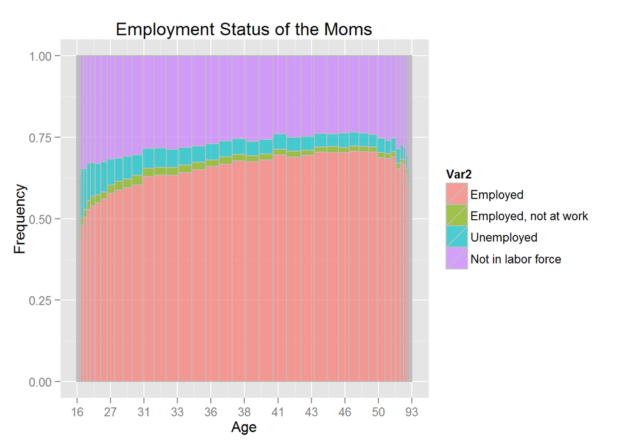

```r
data <- as.data.frame(prop.table(table(am$AGEP, am$ESR)))
data$margin <- prop.table(table(am$AGEP))
data$height <- data$Freq/data$margin
data$center <- c(0, cumsum(data$margin)[1:length(levels(factor(am$AGEP))) -1]) + data$margin/2
ggplot(data, aes(center, height)) +
  geom_bar(stat = "identity", aes(width = margin, fill = Var2), col = "gray", alpha = 0.7) +
  labs(x = "Age", y = "Frequency", title = "Employment Status of the Moms") +
  scale_x_continuous(breaks = seq(0, 1, 0.1), labels=c("16", "27", "31", "33", "36", "38", "41", "43", "46", "50", "93"))
```

### Observation

While it’s largely a personal choice to be a working mom or not, there might be objective factors that influence the mom’s decision. A rough look at the plot of employmennt status showed that overall 65% of the moms were employed and active at work. The proportion of employment steadily increased with the moms’ age among moms younger than 50 years old, suggesting that more moms continued their career track when their kids grew older. Meanwhile, the proportion of being unemployed dropped accordingly with the moms’ age.

### Marital Status vs Employment Status

```r
chisq.test(table(am$MAR, am$ESR))
```

```
##
##  Pearson's Chi-squared test
##
## data:  table(am$MAR, am$ESR)
## X-squared = 8701.7, df = 12, p-value < 2.2e-16
```

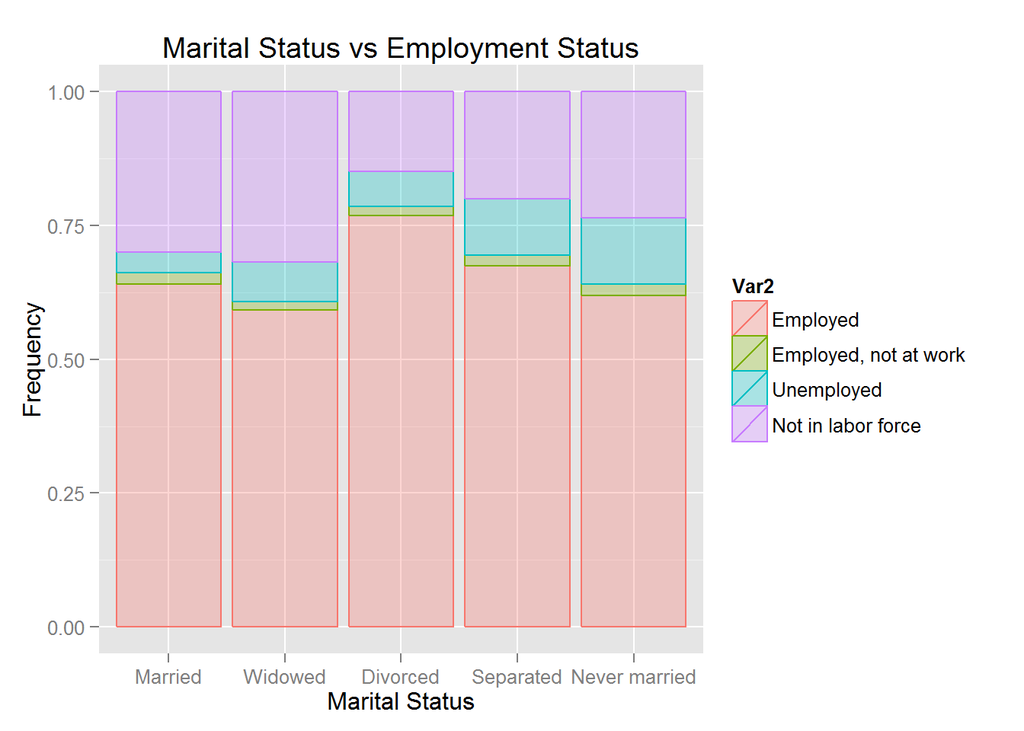

```r
data <- as.data.frame(prop.table(table(am$MAR, am$ESR), margin = 1))
ggplot(data, aes(x = Var1, y = Freq, group = Var2)) +
  geom_bar(stat = "identity", aes(colour = Var2, fill = Var2), alpha = 0.3) +
  labs(x = "Marital Status", y = "Frequency", title = "Marital Status vs Employment Status")
```

### Observation

The Chi square test suggested a highly significant association between marital status and employment status among the moms with dependent children. The highest percentage of being employed were seen in the groups of divorced (77%) and separated (68%) moms, who were most likely to be facing the double pressure of taking care of children and being financially independent.

### Education vs Employment Status

```r
chisq.test(table(am$SCHL, am$ESR))
```

```
##
##  Pearson's Chi-squared test
##
## data:  table(am$SCHL, am$ESR)
## X-squared = 13578, df = 18, p-value < 2.2e-16
```

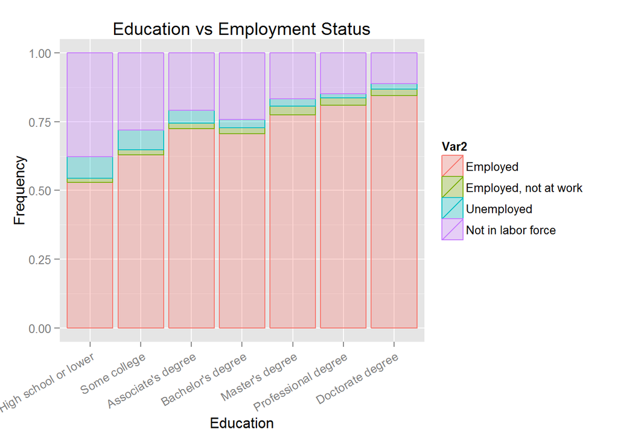

```r
data <- as.data.frame(prop.table(table(am$SCHL, am$ESR), margin = 1))
ggplot(data, aes(x = Var1, y = Freq, group = Var2)) +
  geom_bar(stat = "identity", aes(colour = Var2, fill = Var2), alpha = 0.3) +
  labs(x = "Education", y = "Frequency", title = "Education vs Employment Status") +
  theme(axis.text.x = element_text(angle = 30, hjust = 1))
```

### Observation

The Chi square test also revealed a significant association between education and employment status among the moms. Approximately 80% of the moms with advanced degrees (Master’s degree or higher) were employed and active at work, while the percentage of employment was only about 53% among the moms with high school education or lower.

### Field of the Moms’s Work

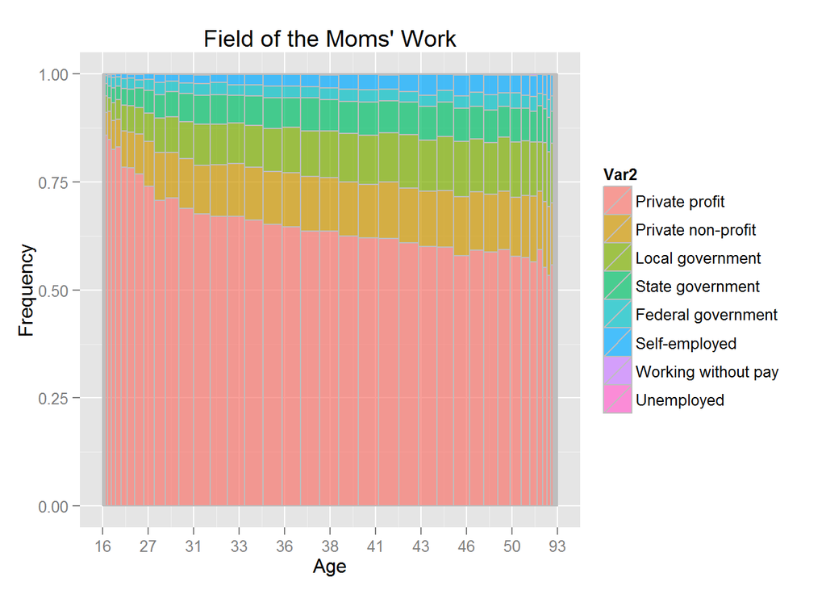

```r
wm <- subset(am, ESR == "Employed" & WAGP > 1000)
data <- as.data.frame(prop.table(table(wm$AGEP, wm$COW)))
data$margin <- prop.table(table(wm$AGEP))
data$height <- data$Freq/data$margin
data$center <- c(0, cumsum(data$margin)[1:length(levels(factor(wm$AGEP))) -1]) + data$margin/2
ggplot(data, aes(center, height)) +
  geom_bar(stat = "identity", aes(width = margin, fill = Var2), col = "gray", alpha = 0.7) +
  labs(x = "Age", y = "Frequency", title = "Field of the Moms' Work") +
  scale_x_continuous(breaks = seq(0, 1, 0.1), labels=c("16", "27", "31", "33", "36", "38", "41", "43", "46", "50", "93"))
```

### Observation

Roughly two-thirds of the moms worked for private profit organizations, while the others worked for private non-profits, governments or was self-employed. The proportions of moms working for the latter categories steadily increased along with the moms’s age.

### Wages of the Working Mom

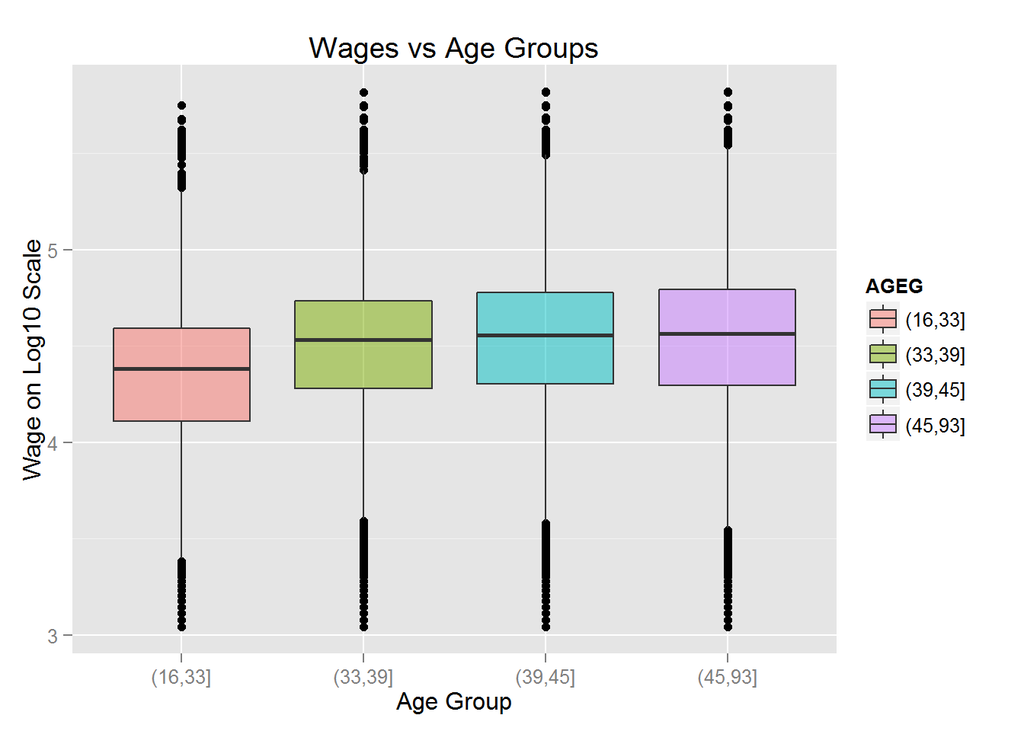

```r
wm$AGEG <- cut(wm$AGEP, breaks = quantile(wm$AGEP))
ggplot(na.omit(wm), aes(x = AGEG, y = log10(WAGP))) +
  geom_boxplot(aes(fill = AGEG), alpha = 0.5) +
  labs(x = "Age Group", y = "Wage on Log10 Scale", title = "Wages vs Age Groups")
```

### Observation

The instances of working moms were divided into four age groups (16 to 33, 34 to 39, 40 to 45, and 46 to 93) according to their age quantiles. When the wages were plotted according to age groups, a significant increment was shown between the first and the second groups. The wages of working moms in the second, third and fourth age groups remained relatively on the same level.

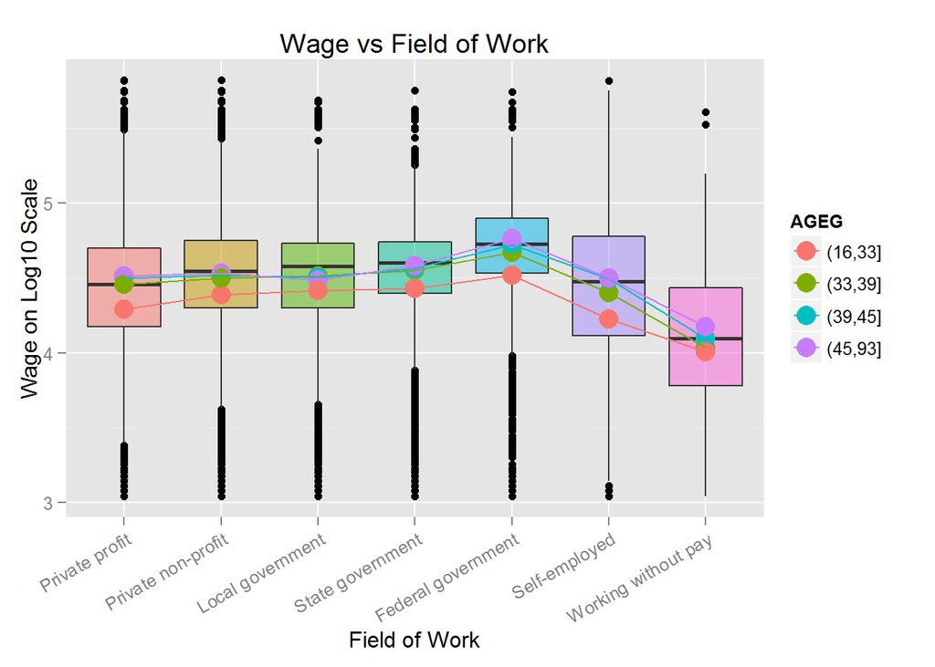

```r
ggplot(na.omit(wm), aes(x = COW, y = log10(WAGP))) +
  geom_boxplot(aes(fill = COW), alpha = 0.5) +
  labs(x = "Field of Work", y = "Wage on Log10 Scale", title = "Wage vs Field of Work") +
  stat_summary(fun.y=mean, aes(colour = AGEG), geom="point", size = 5) +
  stat_summary(fun.y=mean, aes(group=AGEG, colour = AGEG), geom="line") +
  theme(axis.text.x = element_text(angle = 30, hjust = 1)) +
  guides(fill = FALSE)
```

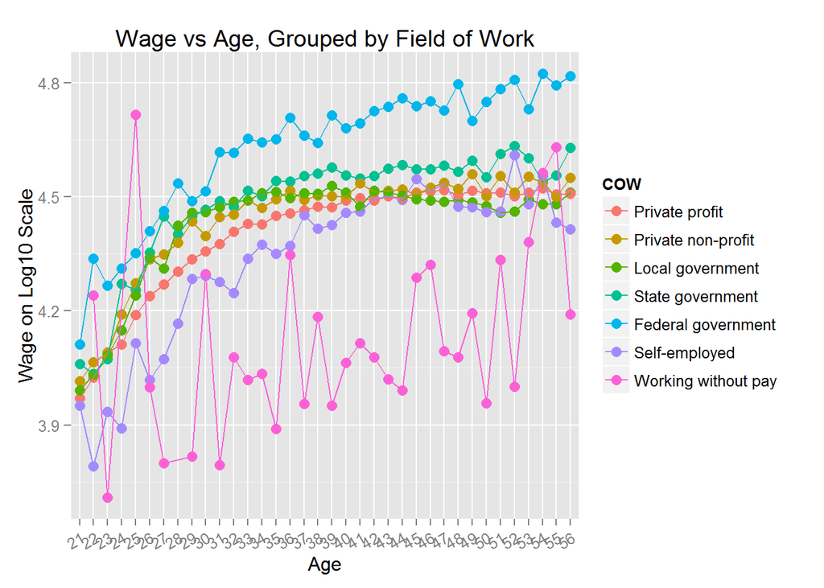

```r
ggplot(subset(wm, AGEP <= 56 & AGEP >= 21), aes(x = factor(AGEP), y = log10(WAGP))) +
  stat_summary(fun.y=mean, aes(colour = COW), geom="point", size = 3) +
  stat_summary(fun.y=mean, aes(group=COW, colour = COW), geom="line") +
  labs(x="Age", y="Wage on Log10 Scale", title="Wage vs Age, Grouped by Field of Work") +
  theme(axis.text.x = element_text(angle = 30, hjust = 1))
```

### Observation

The wages of working moms were plotted according to their field of work, with the mean wage of each age group labeled as points of various colors. Moms working for federal government showed the highest mean wages among all categories of field of work. Still, the group of moms ages 16 to 33 represented the lowest mean wages among the four age groups.

The mean wage of individual field of work was further plotted according to age to illustrate whether age could a confounder between wage and field of work. Although the highest mean wage was consistently shown in the group of moms working for federal government, the wage differences between the moms being self-employed and the moms working for state/local government or private organizations became insignificant when the moms’ ages were older than mid-40. Given the fact that the proportion of moms being self-employed increased along with age, age is likely to be a confounder between the working moms’ wages and fields of work.

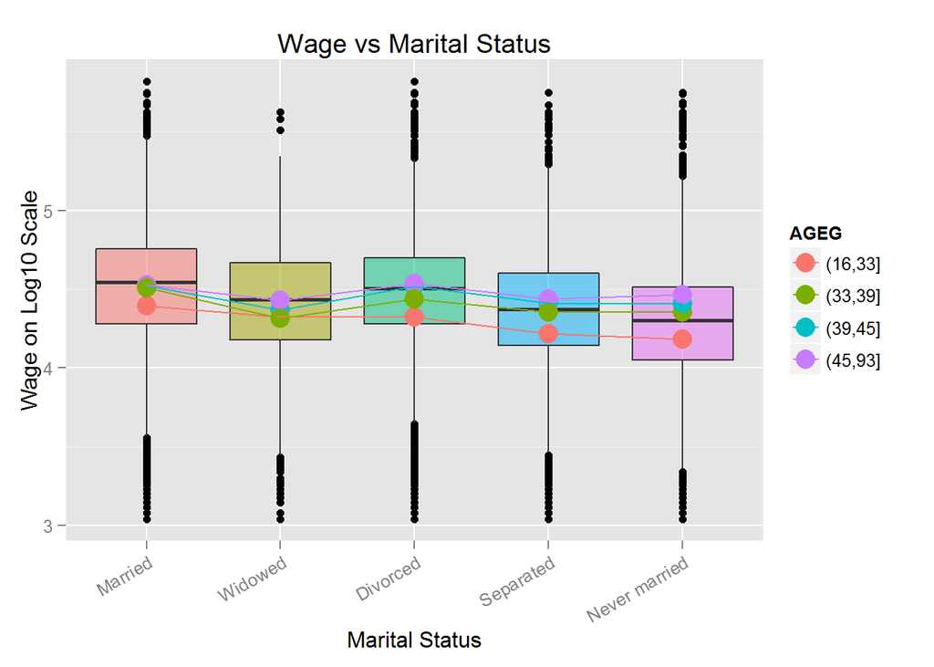

```r
ggplot(na.omit(wm), aes(x = MAR, y = log10(WAGP))) +
  geom_boxplot(aes(fill = MAR), alpha = 0.5) +
  labs(x = "Marital Status", y = "Wage on Log10 Scale", title = "Wage vs Marital Status") +
  stat_summary(fun.y=mean, aes(colour = AGEG), geom="point", size = 5) +
  stat_summary(fun.y=mean, aes(group=AGEG, colour = AGEG), geom="line") +
  theme(axis.text.x = element_text(angle = 30, hjust = 1)) +
  guides(fill = FALSE)
```

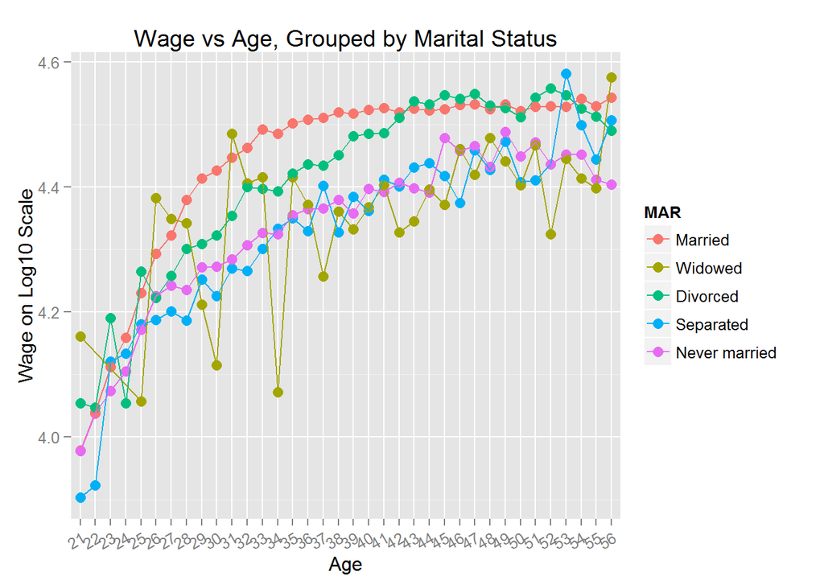

```r
ggplot(subset(wm, AGEP <= 56 & AGEP >= 21), aes(x = factor(AGEP), y = log10(WAGP))) +
  stat_summary(fun.y=mean, aes(colour = MAR), geom="point", size = 3) +
  stat_summary(fun.y=mean, aes(group=MAR, colour = MAR), geom="line") +
  labs(x="Age", y="Wage on Log10 Scale", title="Wage vs Age, Grouped by Marital Status") +
  theme(axis.text.x = element_text(angle = 30, hjust = 1))
```

### Observation

The highest mean wage was shown in the group of married moms, followed by the group of divorced moms. Considering the association between marital status and age, could age be a confounder here between the working moms’ wages and marital status? The answer is probably yes. The wage difference between married moms and divorced moms was no longer seen when the moms’ ages were older than mid-40.

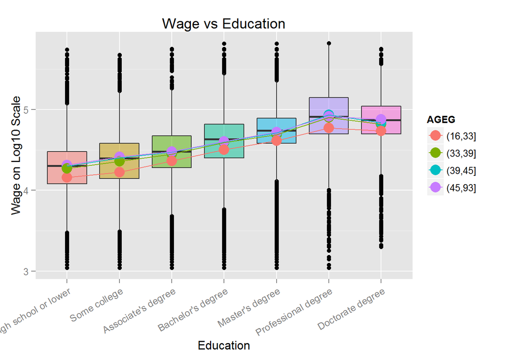

```r
ggplot(na.omit(wm), aes(x = SCHL, y = log10(WAGP))) +
  geom_boxplot(aes(fill = SCHL), alpha = 0.5) +
  labs(x = "Education", y = "Wage on Log10 Scale", title = "Wage vs Education") +
  stat_summary(fun.y=mean, aes(colour = AGEG), geom="point", size = 5) +
  stat_summary(fun.y=mean, aes(group=AGEG, colour = AGEG), geom="line") +
  theme(axis.text.x = element_text(angle = 30, hjust = 1)) +
  guides(fill = FALSE)
```

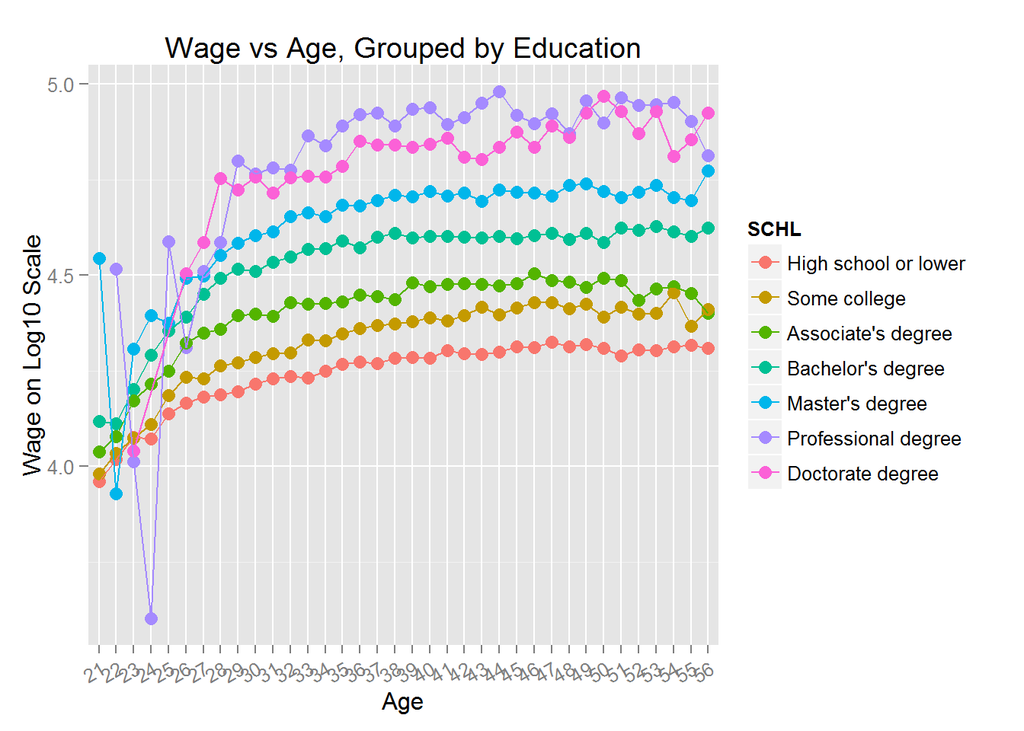

```r
ggplot(subset(wm, AGEP <= 56 & AGEP >= 21), aes(x = factor(AGEP), y = log10(WAGP))) +
  stat_summary(fun.y=mean, aes(colour = SCHL), geom="point", size = 3) +
  stat_summary(fun.y=mean, aes(group=SCHL, colour = SCHL), geom="line") +
  labs(x="Age", y="Wage on Log10 Scale", title="Wage vs Age, Grouped by Education") +
  theme(axis.text.x = element_text(angle = 30, hjust = 1))
```

### Observation

In addition to the higher employment rate, moms with advanced degrees were more likely to have higer wages compared to moms with lower education levels. Although the association between wage and education was blurred among the moms in their 20s, wage was consistently stratified according to education among the moms older than 30 years old. Thus, Age is also likely to be a confounder between the working moms’ wages and education.